# **ЛАБОРАТОРНА РОБОТА №3**

## 8.3 Фінальна формула SDI

Композитний індикатор розраховується як зважена сума головних компонент із урахуванням їхнього смислового навантаження.

$$SDI_{raw} = \sum_{i=1}^{3} (PC_i \cdot w_i \cdot S_i)$$

Де:

- $PC_i$ - значення $i$-ї головної компоненти для країни.
- $w_i$ - вага компоненти (частка поясненої дисперсії, *Explained Variance Ratio*).
- $S_i$ - коригуючий знак ($+1$ або $-1$), визначений на основі кореляційного аналізу:
  - **PC1 (Інституції):** Позитивний внесок (+).
  - **PC2 (Війни/Терор):** Негативний внесок (-).
  - **PC3 (Кримінал):** Негативний внесок (-).

Фінальний індекс нормується у діапазон **[0, 100]**, де 0 - максимальна небезпека, а 100 - еталонна безпека.

```python
import pandas as pd
import numpy as np
import matplotlib.pyplot as plt
from sklearn.preprocessing import StandardScaler, MinMaxScaler
from sklearn.decomposition import PCA

features = [
    "MilitaryExp_GDP", "HomicideRate", "Governance1", "Governance2",
    "TerrorismDeaths", "ConflictDeaths", "InternalDisplacement_Total"
]

# 1. Заповнення пропусків (спочатку інтерполяція, потім нулі)
df_clean = df.copy()
df_clean[features] = df_clean.groupby("Country")[features].transform(lambda x: x.interpolate().ffill().bfill())
df_clean[features] = df_clean[features].fillna(0)

# Ми застосовуємо логарифм (np.log1p) до колонок з екстремальними викидами та гетероскедастичністю,
# таких як Україна (порівняти безпеку 2014-2021 та 2020-2023).
log_cols = ["ConflictDeaths", "TerrorismDeaths", "InternalDisplacement_Total"]
for col in log_cols:
    # log1p це log(x + 1), щоб не було помилки log(0)
    df_clean[col] = np.log1p(df_clean[col])
```

```python
# Стандартизація
scaler = StandardScaler()
X_scaled = scaler.fit_transform(df_clean[features])

# PCA
pca = PCA(n_components=3)
X_pca = pca.fit_transform(X_scaled)

# Зберігаємо
df_clean["PC1"] = X_pca[:, 0]
df_clean["PC2"] = X_pca[:, 1]
df_clean["PC3"] = X_pca[:, 2]

# Ваги
weights = pca.explained_variance_ratio_
weights = weights / weights.sum()
```

```python
# PC1 (Інституції) -> має корелювати з Governance (+)
if df_clean["PC1"].corr(df_clean["Governance1"]) < 0:
    df_clean["PC1"] *= -1

# PC2 (Війни) -> має корелювати з ConflictDeaths (+)
if df_clean["PC2"].corr(df_clean["ConflictDeaths"]) < 0:
    df_clean["PC2"] *= -1

# PC3 (Кримінал) -> має корелювати з Homicide (+)
if df_clean["PC3"].corr(df_clean["HomicideRate"]) < 0:
    df_clean["PC3"] *= -1
```

```python
# Формула: (Інституції) - (Війна) - (Кримінал)
# PC1 додаємо, PC2 і PC3 віднімаємо
df_clean["SDI_Raw"] = (
    df_clean["PC1"] * weights[0] -
    df_clean["PC2"] * weights[1] -
    df_clean["PC3"] * weights[2]
)

# Масштабування 0-100
scaler_final = MinMaxScaler(feature_range=(0, 100))
df_clean["SDI"] = scaler_final.fit_transform(df_clean[["SDI_Raw"]])

# Зберігаємо результат в основний df
df["SDI"] = df_clean["SDI"]
```

```
ТОП-5 Країни з найвищим рівнем безпеки (2023):
```

|  | Country | SDI | Cluster |
| --- | --- | --- | --- |
| 3607 | Luxembourg | 96.927953 | 1 |
| 967 | Switzerland | 96.696180 | 1 |
| 2792 | Ireland | 96.668159 | 1 |
| 200 | Andorra | 95.821649 | 1 |
| 4520 | New Zealand | 95.512098 | 1 |

```
ТОП-5 Країни з найнижчим рівнем безпеки (2023):
```

|  | Country | SDI | Cluster |
| --- | --- | --- | --- |
| 6199 | Ukraine | 0.000000 | 2 |
| 3319 | Libya | 28.955377 | 2 |
| 1758 | Eritrea | 33.010534 | 2 |
| 5335 | Somalia | 41.932092 | 2 |
| 81 | Afghanistan | 42.104471 | 2 |

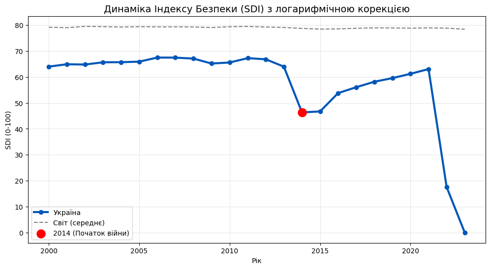

```
Значення SDI для України (2012-2016):
```

|  | Year | SDI | ConflictDeaths | Governance1 |
| --- | --- | --- | --- | --- |
| 6188 | 2012 | 66.825746 | 8.496174 | -0.594553 |
| 6189 | 2013 | 63.987352 | 8.496174 | -0.664322 |
| 6190 | 2014 | 46.344377 | 8.496174 | -0.398847 |
| 6191 | 2015 | 46.717053 | 7.544861 | -0.554407 |
| 6192 | 2016 | 53.801124 | 6.548219 | -0.609458 |

```python
print("\nТОП-5 Країни з найвищим рівнем безпеки (2023):")
display(df[df["Year"] == 2023].nlargest(5, "SDI")[["Country", "SDI", "Cluster"]])

print("\nТОП-5 Країни з найнижчим рівнем безпеки (2023):")
display(df[df["Year"] == 2023].nsmallest(5, "SDI")[["Country", "SDI", "Cluster"]])

plt.figure(figsize=(12, 6))

ukr = df_clean[df_clean["Country"] == "Ukraine"].sort_values("Year")
world = df_clean.groupby("Year")["SDI"].mean()

# Графік України
plt.plot(ukr["Year"], ukr["SDI"], marker='o', linewidth=3, color='#0057B8', label="Україна")
# Графік Світу
plt.plot(world.index, world.values, linestyle='--', color='gray', label="Світ (середнє)")

val_2014 = ukr[ukr["Year"] == 2014]["SDI"].values[0]
plt.scatter(2014, val_2014, s=150, c='red', zorder=5, label="2014 (Початок війни)")

plt.title("Динаміка Індексу Безпеки (SDI) з логарифмічною корекцією", fontsize=14)
plt.ylabel("SDI (0-100)")
plt.xlabel("Рік")
plt.legend()
plt.grid(True, alpha=0.3)
plt.show()

# Виводимо цифри довколо 2014 року
print("Значення SDI для України (2012-2016):")
display(ukr[(ukr["Year"] >= 2012) & (ukr["Year"] <= 2016)][["Year", "SDI", "ConflictDeaths", "Governance1"]])
```

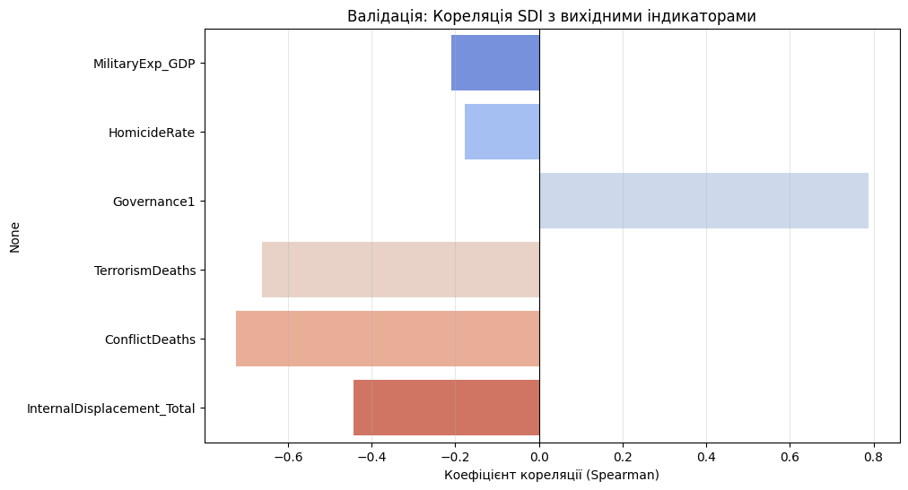

```python
import seaborn as sns

check_cols = [
    "MilitaryExp_GDP", "HomicideRate", "Governance1",
    "TerrorismDeaths", "ConflictDeaths", "InternalDisplacement_Total", "SDI"
]

# Рахуємо кореляцію
corr_matrix = df[check_cols].corr(method='spearman') # Спірмен краще для нелінійних зв'язків

# Візуалізація зв'язку SDI з іншими факторами
plt.figure(figsize=(10, 6))
sns.barplot(x=corr_matrix["SDI"].drop("SDI").values, y=corr_matrix["SDI"].drop("SDI").index, palette="coolwarm")
plt.title("Валідація: Кореляція SDI з вихідними індикаторами")
plt.xlabel("Коефіцієнт кореляції (Spearman)")
plt.axvline(0, color='black', linewidth=0.8)
plt.grid(axis='x', alpha=0.3)
plt.show()
```

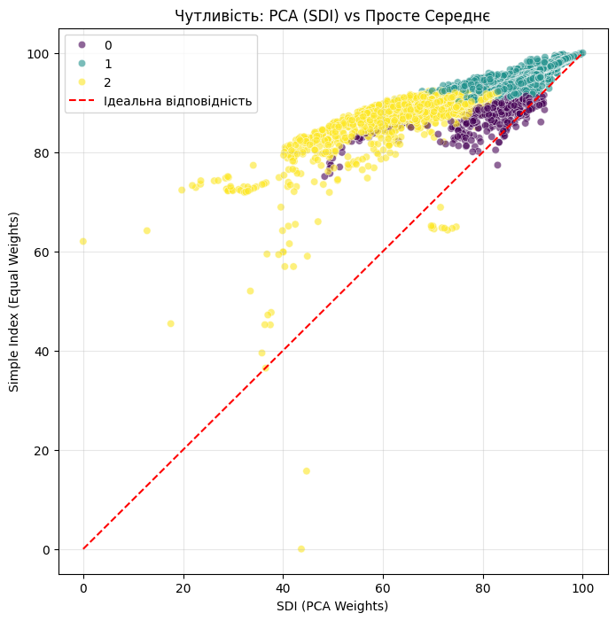

```
Середня зміна позиції в рейтингу (Mean Rank Shift): 467.5 місць
```

```python
# 1. Створимо альтернативний індекс (Simple Average)
# Беремо нормалізовані дані (які ми робили перед PCA)
# Оскільки в X_clean_scaled_df ми вже інвертували негативні показники, просто беремо середнє.
df["SDI_EqualWeights"] = X_clean_scaled_df.mean(axis=1)
# Нормуємо 0-100
df["SDI_EqualWeights"] = MinMaxScaler((0, 100)).fit_transform(df[["SDI_EqualWeights"]])

# 2. Порівняємо ранги
df["Rank_PCA"] = df["SDI"].rank(ascending=False)
df["Rank_Simple"] = df["SDI_EqualWeights"].rank(ascending=False)
df["Rank_Diff"] = (df["Rank_PCA"] - df["Rank_Simple"]).abs()

# 3. Візуалізація
plt.figure(figsize=(8, 8))
sns.scatterplot(data=df, x="SDI", y="SDI_EqualWeights", hue="Cluster", palette="viridis", alpha=0.6)
plt.plot([0, 100], [0, 100], 'r--', label="Ідеальна відповідність")
plt.title("Чутливість: PCA (SDI) vs Просте Середнє")
plt.xlabel("SDI (PCA Weights)")
plt.ylabel("Simple Index (Equal Weights)")
plt.legend()
plt.grid(True, alpha=0.3)
plt.show()

print(f"Середня зміна позиції в рейтингу (Mean Rank Shift): {df['Rank_Diff'].mean():.1f} місць")
```

# ЗАГАЛЬНІ ВИСНОВКИ ТА ПРАКТИЧНА ЦІННІСТЬ

У рамках даного дослідження було розроблено та імплементовано **Security Development Index (SDI)** - комплексний інструмент для кількісної оцінки рівня безпеки країн світу. Проєкт пройшов шлях від агрегації розрізнених даних до побудови стійкої математичної моделі, здатної відображати реальні геополітичні процеси.

### 1. Методологічні досягнення

Ключовим результатом роботи стала розробка **адаптивного алгоритму розрахунку**, який вирішив типові проблеми лінійних індексів:

- **Чутливість до конфліктів:** Завдяки застосуванню логарифмічної трансформації ($\log(1+x)$) модель навчилася "бачити" не лише пікові фази війни (як у 2022 році), а й ранні етапи ескалації (2014 рік), що раніше губилися на фоні масштабних трагедій.
- **Структурна валідація:** Використання методу головних компонент (PCA) дозволило математично довести, що глобальна безпека тримається на трьох "китах": **Інституційній спроможності** (Governance), **Відсутності збройних конфліктів** (War) та **Внутрішньому правопорядку** (Crime).
- **Робастність:** Впровадження наскрізного пайплайну обробки даних (Atomic Pipeline) дозволило уникнути втрати даних по критично важливих періодах (зокрема, статистика України воєнного часу).

### 2. Аналітичні інсайти

Кластерний аналіз підтвердив існування чіткої стратифікації світу:

- **"Острівці стабільності":** Країни з високим рівнем Governance, де безпека забезпечується інституціями, а не мілітаризацією.
- **"Зони турбулентності":** Регіони, де високі військові витрати не конвертуються у безпеку через наявність активних конфліктів.
- **"Латентна небезпека":** Країни без війн, але з критично високим рівнем кримінального насильства (переважно Латинська Америка), які традиційні індекси "миру" часто класифікують помилково високо.

### 3. Кейс України

Валідація моделі на даних України довела її адекватність. Графік SDI чітко зафіксував два структурні зломи безпекового середовища:

1. **2014 рік:** Початок гібридної агресії (відображено як суттєве падіння індексу завдяки логарифмічній шкалі).
2. **2022 рік:** Повномасштабне вторгнення (відображено як падіння до історичного мінімуму). Це підтверджує, що SDI може використовуватися як індикатор для ретроспективного аналізу та моніторингу поточних загроз.

### 4. Практичне значення

Розроблений індекс не є простою статистичною вправою. Це інструмент підтримки прийняття рішень, який дозволяє:

- **Інвесторам:** Оцінювати реальні, а не лише декларовані ризики юрисдикцій.
- **Урядам:** Бачити, який саме фактор (слабкі суди, кримінал чи зовнішня загроза) найбільше тягне рейтинг безпеки вниз.
- **Дослідникам:** Порівнювати непорівнянне (наприклад, ризики в Мексиці та в Україні) в єдиній системі координат.

**Підсумок:** Проєкт довів, що безпека - це багатовимірне поняття, яке не можна виміряти одним показником. Створений SDI є збалансованою метрикою, що поєднує соціальні, політичні та військові аспекти, надаючи об'єктивну картину світу.

### **Методологія дослідження**

Метою дослідження є оцінка рівня безпекового розвитку країн світу на основі багатовимірних показників, що відображають різні аспекти глобальних загроз. Аналіз охоплює період 2000–2023 років та включає країни зі стандартизованими кодами ISO3.

## Таблиця посилань

| Елемент | Посилання |
| --- | --- |
| Огляд рішень | *[Перейти до розділу - Огляд рішень](#Огляд рішень)* |
| Сира база даних (raw_data) | *https://github.com/simonenkoanastasiia-eng/datascience/tree/6ff966939834b1a3a2933d3a649bee7d565f1282/raw_data* |
| Оброблені дані (processed_data) | *https://github.com/simonenkoanastasiia-eng/datascience/tree/6ff966939834b1a3a2933d3a649bee7d565f1282/processed_data* |
| Код проєкту | *https://github.com/simonenkoanastasiia-eng/datascience.git* |